# Tree-Based Methods

## Bagging Example (6/6)

```r
library(ranger)
library(caret)

train_index <- createDataPartition(heart_clean$num_binary, p = 0.7, list = FALSE)
train_data <- heart_clean[train_index, ]
test_data <- heart_clean[-train_index, ]

# Train random forest model - note probability = FALSE for class predictions
rf_model <- ranger(
  num_binary ~ .,           # Formula: predict target using all other variables
  data = train_data,        # Training data
  num.trees = 500,          # Number of trees
  mtry = 13,                # Use all variables for each split
  importance = 'impurity',  # Calculate variable importance (Gini index for classification)
  probability = FALSE       # Get class predictions instead of probabilities
)

# Make predictions on test set - directly get class predictions
predictions <- predict(rf_model, test_data)
pred_class <- predictions$predictions  # Class predictions

# Calculate accuracy
accuracy <- mean(pred_class == test_data$num_binary)

# Get variable importance
var_importance <- data.frame(
  Feature = names(importance(rf_model)),
  Importance = importance(rf_model)
)
# var_importance <- var_importance[order(var_importance$Importance, decreasing = TRUE), ]
var_importance <- as_tibble(var_importance) |>
  arrange(desc(Importance))

var_importance
```

| Feature | Importance |
| --- | --- |
| cp | 22.313815 |
| thal | 17.242619 |
| oldpeak | 10.527061 |
| thalach | 9.977115 |
| chol | 9.520563 |
| age | 8.368015 |
| trestbps | 8.206519 |
| ca | 7.808235 |
| sex | 3.601827 |
| slope | 2.463277 |

[output cut: 3 more lines]

## Evaluation of Bagging Model

```r
# Print results
print("Model Performance:")
```

```
[1] "Model Performance:"
```

```r
print(paste("Accuracy:", round(accuracy, 3)))
```

```
[1] "Accuracy: 0.8"
```

```r
print(paste("Senstivity:", round(sum(pred_class == "yes" & test_data$num_binary == "yes") / sum(test_data$num_binary == "yes"), 3)))
```

```
[1] "Senstivity: 0.78"
```

```r
print(paste("Precision:", round(sum(pred_class == "yes" & test_data$num_binary == "yes") / sum(pred_class == "yes"), 3)))
```

```
[1] "Precision: 0.78"
```

```r
print("Confusion Matrix:")
```

```
[1] "Confusion Matrix:"
```

```r
print(table(Predicted = pred_class, Actual = test_data$num_binary))
```

```
         Actual
Predicted no yes
      no  40   9
      yes  9  32
```

## Variable Importance Plot

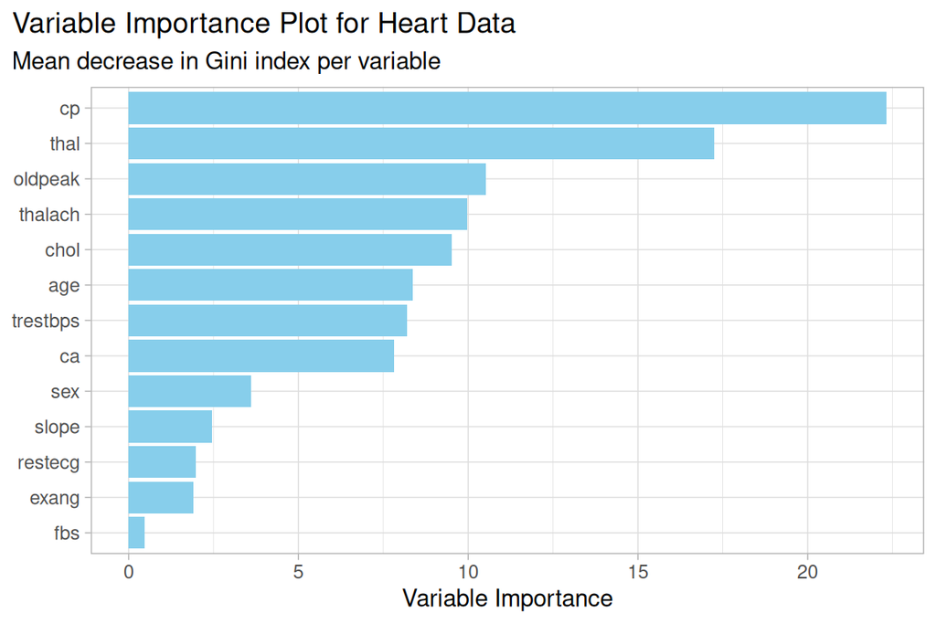

```r
var_importance |>
  ggplot(aes(y = reorder(Feature, Importance), x = Importance)) +
  geom_col(fill = "skyblue") +
  labs(
    title = "Variable Importance Plot for Heart Data",
    subtitle = "Mean decrease in Gini index per variable",
    x = "Variable Importance",
    y = NULL
  ) +
  theme_light() +
  theme(
    plot.title.position = "plot"
  )
```

## Ou-of-Bag Error Estimation

> It turns out that there is a very straightforward way to estimate the test error of a bagged model, without the need to perform cross-validation or the validation set approach. Recall that the key to bagging is that trees are repeatedly fit to bootstrapped subsets of the observations. One can show that on average, each bagged tree makes use of around two-thirds of the observations. The remaining one-third of the observations not used to fit a given bagged tree are referred to as the out-of-bag (OOB) observations.

> . . .

> The resulting OOB error is a valid estimate of the test error for the bagged model, since the response for each observation is predicted using only the trees that were not fit using that observation.

> ISLR2, p 342

## Out-of-Bag Error Plot and results

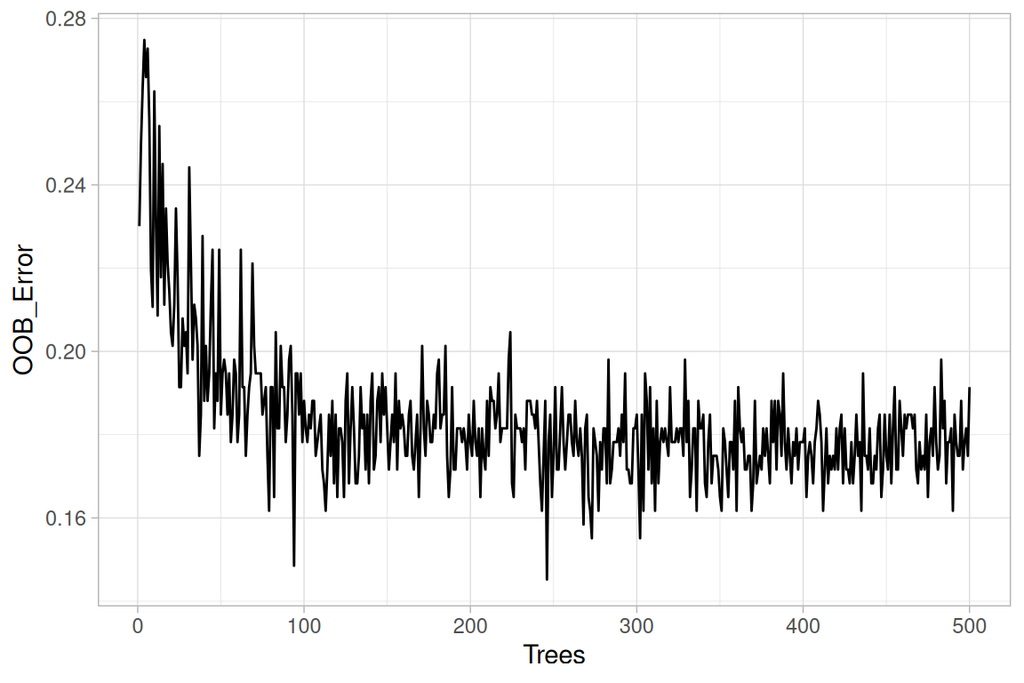

```r
# To track OOB error by number of trees, we can create multiple models
tree_numbers <- 1:500
oob_errors <- numeric(length(tree_numbers))

for(i in seq_along(tree_numbers)) {
  rf_temp <- ranger(
    num_binary ~ .,
    data = heart_clean,
    num.trees = tree_numbers[i],
    importance = 'impurity',
    probability = FALSE,
    oob.error = TRUE
  )
  oob_errors[i] <- rf_temp$prediction.error
}

# Create data frame of results
oob_results <- data.frame(
  Trees = tree_numbers,
  OOB_Error = oob_errors
)

# Print OOB error progression
# print("OOB Error by Number of Trees:")
# print(oob_results)

oob_results |>
  ggplot(aes(x = Trees, y = OOB_Error)) +
  geom_line() +
  theme_light()
```

```r
# Additional model information
print("\nModel Information:")
```

```
[1] "\nModel Information:"
```

```r
print(paste("Number of trees:", rf_model$num.trees))
```

```
[1] "Number of trees: 500"
```

```r
print(paste("Number of independent variables:", rf_model$num.independent.variables))
```

```
[1] "Number of independent variables: 13"
```

```r
print(paste("Mtry:", rf_model$mtry))
```

```
[1] "Mtry: 13"
```

```r
# Get variable importance with OOB error increase
var_importance <- data.frame(
  Feature = names(importance(rf_model)),
  Importance = importance(rf_model)
)
var_importance <- var_importance[order(var_importance$Importance, decreasing = TRUE), ]
```

## Random Forest Example

```r
library(ranger)
library(caret)

set.seed(123)
train_index <- createDataPartition(heart_clean$num_binary, p = 0.7, list = FALSE)
train_data <- heart_clean[train_index, ]
test_data <- heart_clean[-train_index, ]

# Train random forest model - note probability = FALSE for class predictions
rf_model <- ranger(
  num_binary ~ .,           # Formula: predict target using all other variables
  data = train_data,        # Training data
  num.trees = 500,          # Number of trees
  mtry = floor(sqrt(13)),   # Use sqrt(p) variables for each split
  importance = 'impurity',  # Calculate variable importance (Gini index for classification)
  probability = FALSE       # Get class predictions instead of probabilities
)

# Make predictions on test set - directly get class predictions
predictions <- predict(rf_model, test_data)
pred_class <- predictions$predictions  # Class predictions

# Calculate accuracy
accuracy <- mean(pred_class == test_data$num_binary)

# Calculate precision
precision <- sum(pred_class == "yes" & test_data$num_binary == "yes") / sum(pred_class == "yes")

# Calculate sensitivity
sensitivity <- sum(pred_class == "yes" & test_data$num_binary == "yes") / sum(test_data$num_binary == "yes")

print("Model Performance:")
```

```
[1] "Model Performance:"
```

```r
print(paste("Accuracy:", round(accuracy, 3)))
```

```
[1] "Accuracy: 0.822"
```

```r
print(paste("Senstivity:", round(sensitivity, 3)))
```

```
[1] "Senstivity: 0.756"
```

```r
print(paste("Precision:", round(precision, 3)))
```

```
[1] "Precision: 0.838"
```

# Homework

# End of Module 12